# ASSIGNMENT 3

# DATA VISUALISATION

## GROUP C

###### MANPREET KAUR

```python
import plotly
import json
from plotly.tools import FigureFactory as FF
import plotly.figure_factory as ff
import plotly.graph_objs as go
import plotly.plotly as py
from plotly.offline import download_plotlyjs, init_notebook_mode, plot ,iplot
import matplotlib as mpl
import cufflinks as cf
import seaborn as sns
import matplotlib.pyplot as plt
import pandas as pd
import numpy as np
from plotly.offline import download_plotlyjs, init_notebook_mode, plot ,iplot
import plotly
import cufflinks as cf
```

```python
#plotly.tools.set_credentials_file(username='prafuldevmk', api_key='qn8uxFZGAgrAEM5x0m4p')
#plotly.tools.set_credentials_file(username='anaswaraeantony', api_key='NJsHDkz9tqVxGMs4qPFQ')
#plotly.tools.set_credentials_file(username='rameez_raza', api_key='9cnSwawJNNP2XLQnJ37n')
#plotly.tools.set_credentials_file(username='Ranajay', api_key='aCzVlD35RJ94Z26viZ6r')
#plotly.tools.set_credentials_file(username='persie_22', api_key='dcB5JGa2eZ9LWhdAzBX4')
#plotly.tools.set_credentials_file(username='vrb1920', api_key='7uuMV7OalRIrPc71pPUp')
#plotly.tools.set_credentials_file(username='harjeet.singh.lko321@gmail.com', api_key='bXbLauEeD193HqXNxUeJ')
#plotly.tools.set_credentials_file(username='plotlyharsh89', api_key='ipX45ZVxWWAuRpUKVxF8')
#plotly.tools.set_credentials_file(username='DakshitaTiwari', api_key='IwGjGEkLoll23i7ND3oT')
#plotly.tools.set_credentials_file(username='harjeet.singh.lko321@gmail.com', api_key='bXbLauEeD193HqXNxUeJ')
plotly.tools.set_credentials_file(username='zeet.321@gmail.com', api_key='RHZE5QMi3demNzeOipG6')
```

```python
init_notebook_mode(connected=True)
cf.go_offline()
```

```python
gm=pd.read_csv('https://raw.githubusercontent.com/plotly/datasets/master/gapminderDataFiveYear.csv')
```

```python
gm.columns
```

# WHAT GAP MINDER IS

Gapminder is an independent Swedish foundation with no political, religious or economic affiliations. Gapminder is a fact tank, not a think tank. Gapminder fights devastating misconceptions about global development. Gapminder produces free teaching resources making the world understandable based on reliable statistics. Gapminder promotes a fact-based worldview everyone can understand. Gapminder collaborates with universities, UN, public agencies and non-governmental organizations. All Gapminder activities are governed by the board. We do not award grants. Gapminder Foundation is registered at Stockholm County Administration Board.

# ABOUT DATA SET

This data consists of columns like country (Name of Countries), year (Year of analysis) ,pop (Population of that same country), continenet (name of the continent from where that country belongs, lifeExp (its average age of person in that perticular country in that age), gdpPercap (shows gross domestic product of countries). This data is from year 1952 to 2007

# HISTOGRAPH OF EVERY NUMERIC COLUMN

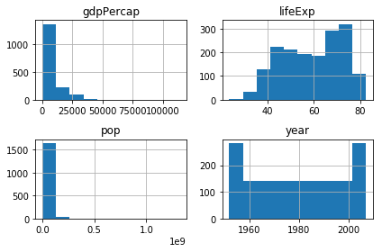

```
High five! You successfully sent some data to your account on plotly. View your plot in your browser at https://plot.ly/~zeet/0 or inside your plot.ly account where it is named 'GAP MINDER'
```

[interactive chart not shown]

```python
gm=pd.read_csv('https://raw.githubusercontent.com/plotly/datasets/master/gapminderDataFiveYear.csv')
plt.figure(figsize=(55,55))
gm[['country','year','pop','continent','lifeExp','gdpPercap']].hist()
plt.tight_layout()
plt.show()

a=gm['pop'],gm['lifeExp'],gm['gdpPercap'],gm['year']
trace=go.Surface(colorscale='Earth',z=a)
data=[trace]
fig = go.Figure(data=data)
py.iplot(fig, filename='GAP MINDER')
```

###### FROM ABOVE GRAPHS WE CAN SEE THAT GDP AND POPULATION ARE OF SHOWING SAME TREND AND AROUND 65 TO 70 LIFE EXPECTENCIES ARE MORE AS COMPARED TO OTHERS

```python
gm=pd.read_csv('https://raw.githubusercontent.com/plotly/datasets/master/gapminderDataFiveYear.csv')
gm=gm[gm.country=='India']

gm.iplot(kind='bubble',x='year',y='pop',size='gdpPercap',xTitle='year',yTitle='population',
              title='Year Wise Relation B/W Population And GDP per capita Of INDIA',theme='solar',width=5)

trace=go.Scatter3d(x=gm['year'],y=gm['pop'],z=gm['gdpPercap'],mode='lines')
data=[trace]

layout = dict(
    height=800, width=800, title='Year Wise Relation B/W Population And GDP per capita Of INDIA',
    scene=dict(
        xaxis=dict(title='year'),
        yaxis=dict(title='population'),
        zaxis=dict(title='gdp per capita'),
        camera=dict(
            eye=dict(x=-1.7, y=-1.7, z=0.5)
        )
    )
)


fig = go.Figure(data=data,layout=layout)
py.iplot(fig, filename='line chart')
```

[interactive chart not shown]

from year 1950 to 2000 we can see that as indian population increses its gdp also incr

this shows that both part of gdp i.e numerator and denominator increases simultaneously

```python
gm=pd.read_csv('https://raw.githubusercontent.com/plotly/datasets/master/gapminderDataFiveYear.csv')
gm=gm[gm.country=='India']

gm.iplot(kind='bubble',x='year',y='pop',size='lifeExp',xTitle='year',yTitle='population',
              title='Year Wise Relation B/W Population And Life Expectency Of INDIA',theme='solar',width=5)


trace=go.Scatter3d(x=gm['year'],y=gm['pop'],z=gm['lifeExp'],mode='markers')
data=[trace]

layout = dict(
    height=800, width=800, title='Year Wise Relation B/W Population And Life Expectency Of INDIA',
    scene=dict(
        xaxis=dict(title='year'),
        yaxis=dict(title='population'),
        zaxis=dict(title='life expectencies'),
        camera=dict(
            eye=dict(x=-1.7, y=-1.7, z=0.5)
        )
    )
)

fig = go.Figure(data=data,layout=layout)
py.iplot(fig, filename='makers')
```

[interactive chart not shown]

from year 1950 to 2000 we can see that as indian life expectancies increses as population incr this is beacause now days we have better medical treatments, doctors and good health awareness

```python
df = pd.read_csv('https://raw.githubusercontent.com/plotly/datasets/master/gapminderDataFiveYear.csv')

trace1 = go.Scatter3d(
    x=df['year'][750:1500],
    y=df['continent'][750:1500],
    z=df['pop'][750:1500],
    text=df['country'][750:1500],
    mode='markers',
    marker=dict(
        sizemode='diameter',
        sizeref=750,
        size=df['gdpPercap'][750:1500],
        color = df['lifeExp'][750:1500],
        colorscale = 'Viridis',
        colorbar = dict(title = 'Life<br>Expectancy'),
        line=dict(color='rgb(140, 140, 170)')
    )
)

data=[trace1]

#layout=go.Layout(height=800, width=800, title='Examining Population and Life Expectancy Over Time')

layout = dict(
    height=800, width=800, title='Examining Population and Life Expectancy Over Time',
    scene=dict(
        xaxis=dict(title='years'),
        yaxis=dict(title='continents'),
        zaxis=dict(title='population'),
        camera=dict(
            eye=dict(x=-1.7, y=-1.7, z=0.5)
        )
    )
)


fig=go.Figure(data=data, layout=layout)
py.iplot(fig, filename='3DBubble')
```

[interactive chart not shown]

and now every continents are on almost sme graph of life expectencies

```python
url_csv = 'http://www.stat.ubc.ca/~jenny/notOcto/STAT545A/examples/gapminder/data/gapminderDataFiveYear.txt'

df = pd.read_csv(url_csv, sep='\t')
df.head()

countries = ['China', 'India', 'United States', 'Bangladesh', 'South Africa']
fill_colors = ['#66c2a5', '#fc8d62', '#8da0cb', '#e78ac3', '#a6d854']
gf = df.groupby('country')

data = []

for country, fill_color in zip(countries[::-1], fill_colors):
    group = gf.get_group(country)
    years = group['year'].tolist()
    length = len(years)
    country_coords = [country] * length
    pop = group['pop'].tolist()
    zeros = [0] * length

    data.append(dict(
        type='scatter3d',
        mode='lines',
        x=years + years[::-1] + [years[0]],  # year loop: in incr. order then in decr. order then years[0]
        y=country_coords * 2 + [country_coords[0]],
        z=pop + zeros + [pop[0]],
        name='',
        surfaceaxis=1, # add a surface axis ('1' refers to axes[1] i.e. the y-axis)
        surfacecolor=fill_color,
        line=dict(
            color='black',
            width=4
        ),
    ))

layout = dict(
    title='Population from 1957 to 2007',
    showlegend=False,
    scene=dict(
        xaxis=dict(title='year'),
        yaxis=dict(title='country'),
        zaxis=dict(title='population'),
        camera=dict(
            eye=dict(x=-1.7, y=-1.7, z=0.5)
        )
    )
)

fig = dict(data=data, layout=layout)

# IPython notebook
# py.iplot(fig, filename='filled-3d-lines')

py.iplot(fig, filename='filled-3d-lines')
```

[interactive chart not shown]